# Vote choice models from post-referendum panel / take1

by Laszlo

November 17, 2016

Below my attempts at model building, and teasing out the marginal effects of interest.

First I present the calculation of prior weights. These are assigned to each respondent to correct for our sample imbalance on the distribution of: referendum vote share, region, gender, age, and education.

The target joint totals of these variables come from the BES pre-referendum wave.

Note that this is not the solution I was aiming for in terms of weighting, but I am not sure how much more time I need to get help with the better solution, so let’s work with what we have. :)

What follows after is a series of mixed-effect models. The outcome variable is probability to vote ‘leave’, and the host of predictors is gradually expanded from geographic-demographic variables to the more interesting ones.

I will try to pick up on the following topics under each step: changes in model fit, variance components, and effect sizes in terms of predicted probabilities.

By default, tables and plots are printed on this page. If you wish to look at the R code, click `CODE` wherever it appears.

# Prior weights

I’ve found it best to treat any VAA-sample and the opt-in panels as likely voter samples. There are non-voters in our panel, but as their number is really small (and not well distributed across the other geographic-demographic variables), complex weighting would assign very high frequency weights to a handful of observations while put essentially zero weights to the majority of the observations.

Thus the benchmark I am using is the BES pre-referendum wave’s likely voter sub-sample. I.e. I have discarded respondents there who indicated low or zero probablity to turn out at the referendum.

I have cross-tabulated the BES sample into geographic-demographic cells. I have tried to make these cells as large as possible, as fine partitioning would risk that there would be no corresponding cells in our panel data.

The cells are all observed combinations of region (11, there is no Northern Ireland in there), gender, age (4 broad categories), and 7 education levels (no qualifications (0), GSCE D-G (1), GSCE A*-C (2), A-level (3), Undergraduate (4), Postgraduate (5), Other, non-formal qualification (6)).

```r
setwd("C:/Users/lhorvath/Dropbox/office/kieskompas/data/Brexit/lorenza")
library(data.table)

load("bx.Rda") # bx is our sample
load("bx.5.Rda") # bx.5. is a chunk of it without missing data on any of the weighting variables
load("bes.pop5.Rda") # bes.pop5 is my cross-tabulation of the BES likely voter sub-sample on the weighting variables
```

After doing the same in the panel data, I have calculated the mismatch between the two in terms of observed frequencies. Here is an overview of what I have found:

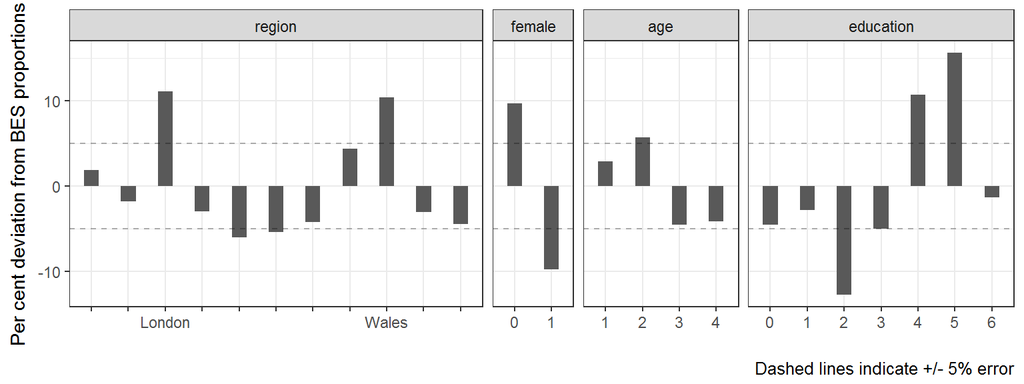

```r
library(ggplot2)
library(gridExtra)

p.err <- rbind(merge(bes.pop5[, .(bes = sum(Freq)), by = region],
    bx.5[, .(sample = .N), by = region], by = "region")[, `:=`(error,
    ((sample - bes)/2232))][, `:=`(cat, region)][, `:=`(cat,
    ordered(cat, labels = c("", " ", "London", "   ", "    ",
        "     ", "      ", "       ", "Wales", "         ", "          ")))][,
    5:4, with = FALSE], merge(bes.pop5[, .(bes = sum(Freq)),
    by = female], bx.5[, .(sample = .N), by = female], by = "female")[,
    `:=`(error, ((sample - bes)/2232))][, `:=`(cat, female)][,
    5:4, with = FALSE], merge(bes.pop5[, .(bes = sum(Freq)),
    by = age], bx.5[, .(sample = .N), by = age], by = "age")[,
    `:=`(error, ((sample - bes)/2232))][, `:=`(cat, age)][, 5:4,
    with = FALSE], merge(bes.pop5[, .(bes = sum(Freq)), by = edlevel],
    bx.5[, .(sample = .N), by = edlevel], by = "edlevel")[, `:=`(error,
    ((sample - bes)/2232))][, `:=`(cat, edlevel)][, 5:4, with = FALSE])
p.err$var <- c(rep("region", 11), rep("female", 2), rep("age",
    4), rep("education", 7))
p.err$var <- ordered(p.err$var, levels = c("region", "female",
    "age", "education"), labels = c("region", "female", "age",
    "education"))

plot.err <- ggplot(p.err, aes(cat, 100 * error)) + geom_col(width = 0.4) +
    theme_bw() + geom_hline(yintercept = 5, linetype = "dashed",
    alpha = 0.3) + geom_hline(yintercept = -5, linetype = "dashed",
    alpha = 0.3) + facet_grid(. ~ var, scales = "free_x", space = "free_x") +
    xlab("") + ylab("Per cent deviation from BES proportions") +
    labs(caption = "Dashed lines indicate +/- 5% error")
plot.err
```

Let’s not forget that the BES is a sample itself. About 5 per cent mismatch between our sample and the BES may not be a big problem. Where we do have problems though are:

- over-sampled London and Wales respondents. Latter is because we have included emails collected through a Welsh voting advice application.
- gender
- massive under-sampling of GSCE-educated likely voters, and over-sampling of university-educated voters.

This is not new given what we know about opt-in online sample users and a lot of the VAA research backs this up as well. We just need to make sure we note and reference it.

Next I am computing weights by fitting the joint totals of the geographic-demographic variables. On top of these weights I have also fitted the regional leave vote share distribution via a method called raking.

The code below does all this silently.

```r
library(survey)

pop1 <- bes.pop5[,.(Freq=sum(Freq)),by=list(region,female,age,edlevel)][order(region,female,age,edlevel)] # query for ps joints
pop2 <- bes.pop5[,.(Freq=sum(Freq)),by=list(region,leave)][order(region,leave)][leave!=2,,] # query for vote share p region

bx.5 <- bx.5[region!="London" | female!=0 | age!=4 | edlevel!=1,,]

#bx.5$w <- NULL
bx.s <- svydesign(ids=~1,data=bx.5)
bx.ps <- postStratify(bx.s,~region+female+age+edlevel,population=pop1,partial=TRUE)
bx.r <- postStratify(bx.ps,~region+leave,pop2)
bx.5$w <- weights(bx.r)
#range(weights(bx.r),na.rm=TRUE)
bx.r <- svydesign(ids=~1, weights = ~w, data=bx.5[!is.na(w),,])
bx.rr <- trimWeights(bx.r,lower=0.001,upper=10)
bx.5[!is.na(w)]$w <- weights(bx.rr)
```

Because of the raking component, the obtained marginal distributions won’t be exactly the same as in the BES, which I don’t mind: again, the BES is a sample, my method of selecting likely voters is arbitrary.

Also, in terms of our expectations of the leave vote share, I also wouldn’t mind it being off +/- few per cents, given how close and unpredictable the elections were. And many may have changed their minds between the BES data collection and the referendum data, we kind of allow for that like this.

Below is the regional distribution of our (weighted-observed) leave vote shares, compared with the unweighted and the official results:

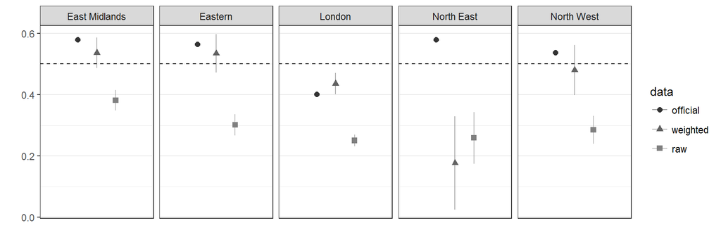

```r
reg.vote <- data.frame(mean=rep(NA,11),SE=rep(NA,11))
rownames(reg.vote) <- levels(bx.5$region)

for (i in rownames(reg.vote)){
  reg.vote[i,] <- data.frame(svymean(~leave,na.rm=TRUE,subset(bx.rr,region==i)))
}

raw.vote <- data.frame(mean=rep(NA,11),SE=rep(NA,11))
rownames(raw.vote) <- levels(bx.5$region)

for (i in rownames(raw.vote)){
  raw.vote[i,] <- data.frame(svymean(~leave,subset(bx.s,region==i)))
}

official.vote <- data.frame(mean=c(.58,.565,.401,.580,.537,.380,.518,.526,.525,.593,.577),SE=rep(NA,11))
rownames(official.vote) <- rownames(reg.vote)

vote <- rbind(reg.vote,raw.vote,official.vote)
vote$data <- rep(c("weighted","raw","official"),each=11)
vote$data <- ordered(vote$data,levels=c("official","weighted","raw"),labels=c("official","weighted","raw"))
vote$region <- rep(rownames(reg.vote),3)

vote$region[vote$region=="Yorkshire and The Humber"] <- "Yorkshire&TH"
vote$split <- 2
vote$split[vote$region==vote$region[c(1:5,12:17)]] <- 1

vote <- as.data.table(vote)


ggplot(data=vote[split==1,,], mapping = aes(x=region,y=mean,ymin=mean-(SE),ymax=mean+(SE),colour=data,group=data)) +
  geom_point(size=2, aes(shape=data),position=position_dodge(width = 0.5)) +
  geom_errorbar(width=0,position=position_dodge(width = 0.5),alpha=0.5) +
  theme_bw() +
  facet_grid(. ~ region, scales="free_x") +
  xlab("") +
  ylab("") +
  scale_x_discrete(breaks=c("")) +
  scale_colour_grey(start=.2,end=.5) +
  geom_hline(yintercept=.5,linetype="dashed")
```

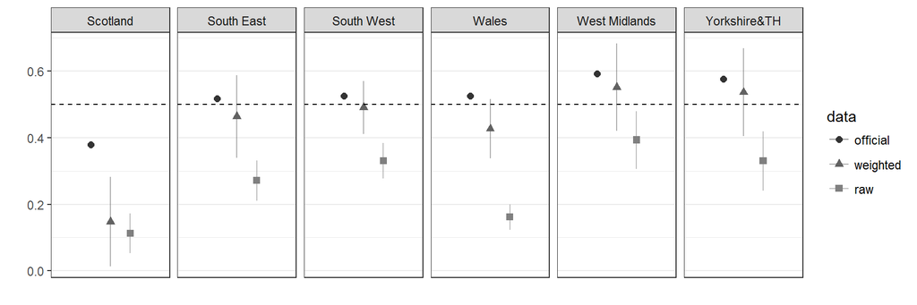

```r
ggplot(data=vote[split==2,,], mapping = aes(x=region,y=mean,ymin=mean-(SE*1.96),ymax=mean+(SE*1.96),colour=data,group=data)) +
  geom_point(size=2, aes(shape=data),position=position_dodge(width = 0.5)) +
  geom_errorbar(width=0,position=position_dodge(width = 0.5),alpha=0.5) +
  theme_bw() +
  facet_grid(. ~ region, scales="free_x") +
  xlab("") +
  ylab("") +
  scale_x_discrete(breaks=c("")) +
  scale_colour_grey(start=.2,end=.5) +
  geom_hline(yintercept=.5,linetype="dashed")
```

This is a much more reasonable picture of the distribution of leave/remain preferences, though we’re off in the North East. A lot changes in how I reassign weights (in the code above I trimmed very large weights otherwise the models below won’t converge), so I may be able to fix this later but I think this will be fine to work with.

Most packages that fit mixed effects/multilevel models can accomodate prior weights, such as I just computed above, and that’s how I will proceed below.

# Model building

I am using multilevel models primarily to account for the regional, base-line variation in the vote share, as quite apparent from the plots above. Failure to account for this would be problematic (spatial auto-correlation, and the variances (significance levels) of the other IV’s would be incorrect).

I am also making attempts to analyse linked data below. That is, I got some data on UKIP vote shares per consitutency, deprivation rates, health statistics, the percentage of non-British whites, the percentage of post-2004 EU migrants. I have aggregated all these to the regional level.

A word of caution with the linked data: these will only vary at the regional level, currently. This means that we may not have enough degrees of freedom to find anything statistically significant (think running a regression on 11 cases.) I can (and I will), however, vary them on a smaller, city-level, because I know the post-code of our respondents. More on that later.

## Model 0: Regions

This means that the simplest model will always include a random intercept for each region. That is, minimally, I am asking for:

$$Pr(y_i = leave | y_i \in {leave, remain}) = logit^{-1}(\beta_0 + u^{region}_{j[i]})$$
which would allow me to extract 11 ‘leave’ probabilities, by adding up the (inverse logit of) the intercept $\beta_0$ and the random intercepts corresponding to the 11 $j$’s in $u^{region}_{j[i]}$, respectively.

The code below demonstrates just that. The output printed is the regional level ‘predictions’, consistent with the plot above:

```r
library(lme4)
library(arm)
model0 <- glmer(leave ~ 1 + ( 1 | region),data=bx.5,weights=w,family=binomial(link="logit"))
summary(model0)
```

```
## Generalized linear mixed model fit by maximum likelihood (Laplace Approximation) ['glmerMod']
##  Family: binomial  ( logit )
## Formula: leave ~ 1 + (1 | region)
##    Data: bx.5
## Weights: w
##
##      AIC      BIC   logLik deviance df.resid
##   2829.7   2840.5  -1412.8   2825.7     1637
##
## Scaled residuals:
##     Min      1Q  Median      3Q     Max
## -3.1513 -0.8541 -0.5489  0.8020  6.9645
##
## Random effects:
##  Groups Name        Variance Std.Dev.
##  region (Intercept) 0.348    0.5899
## Number of obs: 1639, groups:  region, 11
##
## Fixed effects:
##             Estimate Std. Error z value Pr(>|z|)
## (Intercept)  -0.1872     0.1854   -1.01    0.313
```

```
  + predictions:
```

```r
invlogit(fixef(model0) + ranef(model0)$region)
```

```
##                          (Intercept)
## East Midlands              0.5320165
## Eastern                    0.5304843
## London                     0.4365816
## North East                 0.2292002
## North West                 0.4790846
## Scotland                   0.1709277
## South East                 0.4636500
## South West                 0.4892294
## Wales                      0.4290200
## West Midlands              0.5464079
## Yorkshire and The Humber   0.5325068
```

The random intercept term, $u_{j[i]}$’s variance is the variance component attirubted to regional variation. Were this a linear model, this over the residual variance would tell us how much of the total variance is attributed to region. This being a logistic regression, however, I can’t easily answer that (because there is no residual variance/deviance), but I can follow through how the variance components change from one model to another.

From this point on, we are free to include fixed effects (further $\beta$’s, either individual or regional level predictors) as well as varying slopes, which means that the value of that parcticular $\beta$ will be different depending on which region we’re talking about.

And keep this in mind, because you may want to ask me to re-run a model, for instance you may be interested in the effect of eduation on voting leave—depending on region.

Last note about the random effect: if you want to know the ‘effect’ of a particular region at any point, what we have is the conditional mode of that random variable, namely the intercept above. It doesn’t come with standard errors, but I can easily simulate (approximate) a posterior distribution of those random intercepts, so I can draw bounds around them, if needed for the paper.

## Model 1: Socio-demographics

In which I’m adding age, gender, and education fixed-effects. I am not varying the slopes at this point, but let me know if you want to take a peak.

Data tweaks: I’m using the continuous age variable, rather than the categories I used for weighting. I am using an ordered categorical education variable, which follows the original levels except that at level 6, which is non-formal qualification, I assigned missing values (thus our sample size shrinks).

```r
bx.full <- as.data.table(read.csv("postbrexit.csv"))
bx <- merge(bx.5,bx.full[,c(9,21),with=FALSE],by.x="token",by.y="ResponseId",all.x=TRUE)
bx$age.c <- 2016 - bx$q1

bx$ed.c <- bx$edlevel
bx$ed.c[bx$ed.c==6] <- NA

model1 <- glmer(leave ~ 1 + ( 1 | region) + age.c + factor(female) + ordered(factor(ed.c)),data=bx,weights=w,family=binomial(link="logit"))
summary(model1)
```

```
## Generalized linear mixed model fit by maximum likelihood (Laplace Approximation) ['glmerMod']
##  Family: binomial  ( logit )
## Formula: leave ~ 1 + (1 | region) + age.c + factor(female) + ordered(factor(ed.c))
##    Data: bx
## Weights: w
##
##      AIC      BIC   logLik deviance df.resid
##   2294.1   2341.8  -1138.1   2276.1     1464
##
## Scaled residuals:
##     Min      1Q  Median      3Q     Max
## -5.3873 -0.7079 -0.4206  0.8002  5.4446
##
## Random effects:
##  Groups Name        Variance Std.Dev.
##  region (Intercept) 0.4402   0.6635
## Number of obs: 1473, groups:  region, 11
##
## Fixed effects:
##                         Estimate Std. Error z value Pr(>|z|)
## (Intercept)             -0.75841    0.28270  -2.683 0.007303 **
## age.c                    0.01625    0.00327   4.968 6.75e-07 ***
## factor(female)1         -0.28019    0.10519  -2.664 0.007731 **
## ordered(factor(ed.c)).L -1.08310    0.22671  -4.777 1.78e-06 ***
## ordered(factor(ed.c)).Q -0.70117    0.19210  -3.650 0.000262 ***
## ordered(factor(ed.c)).C  0.56753    0.19251   2.948 0.003198 **
## ordered(factor(ed.c))^4  0.31363    0.17518   1.790 0.073401 .
## ordered(factor(ed.c))^5 -0.28746    0.12845  -2.238 0.025226 *
## ---
## Signif. codes:  0 '***' 0.001 '**' 0.01 '*' 0.05 '.' 0.1 ' ' 1
##
## Correlation of Fixed Effects:
##             (Intr) age.c  fct()1 o((.)).L o((.)).Q o((.)).C o((.))^4
## age.c       -0.597
## factr(fml)1 -0.175 -0.005
## ordr((.)).L -0.208  0.263 -0.025
## ordr((.)).Q  0.163 -0.131  0.079  0.063
## ordr((.)).C  0.159 -0.066 -0.070  0.187   -0.076
## ordr((.))^4 -0.112  0.065  0.107  0.317    0.347   -0.498
## ordr((.))^5 -0.002  0.127 -0.069 -0.043   -0.025    0.434   -0.506
## convergence code: 0
## Model failed to converge with max|grad| = 0.0458282 (tol = 0.001, component 1)
```

(Let’s discard the convergence problem at the end of the output, I can deal with that once we selected the final models to report.)

We have improved on our model fit statistics (AIC,BIC), but this still isn’t a well fitting model.

Effect sizes: everything’s just as expected.

I’m putting effect of education in terms of predicted probabilities, holding age constant, for the male population, on the example of three regions, and plotting it below:

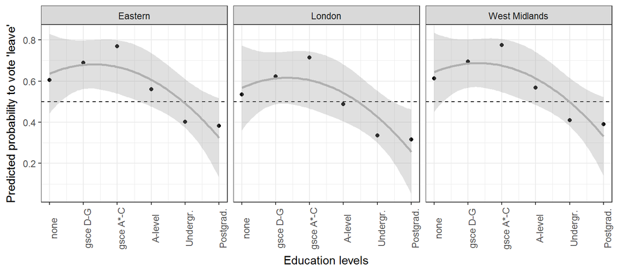

```r
nd <- data.table(
    region=rep(c(levels(bx$region)),6),
    ed.c=rep(c(0,1,2,3,4,5),each=11),
    age.c=rep(mean(bx$age.c),6*11),
    female=rep(0,6*11)
    )
nd$pred <- predict(model1,newdata=nd,type="response")
nd$pred.pop <- predict(model1,newdata=nd,type="response",re.form=NA)

qplot(x=ed.c,y=pred,data=nd[region=="London" | region=="West Midlands" | region=="Eastern"]) +       theme_bw() +
      facet_grid(.~region) +
      geom_hline(yintercept=.5,linetype="dashed") +
      ylab("Predicted probability to vote 'leave'") +
      xlab("Education levels") +
      geom_smooth(method=lm,level=.9,se=TRUE,formula=y~x+I(x^2),na.rm=TRUE,colour="grey69",alpha=0.3) +
      scale_x_continuous("Education levels", breaks=c(0,1,2,3,4,5), labels = c("none","gsce D-G","gsce A*-C","A-level","Undergr.","Postgrad.")) +
      theme(axis.text.x=element_text(angle=90))
```

Now the above explanation should make more sense: general sense of negative relationship, curviliniar, has bits of positive slopes. The effect ‘shape’ is the same across these examples (remember, this is not a random slope model).

This may give an indication of Lorenza’s squeezed middle class argument. At higher GSCE grades we get higher probability to leave than in lower grades. And, even in London, the the remain side is just edging the predicted vote of the A-level people. This same group is well on the leave side in the Midlands and the East of England.

Suggestion: depending on model complexity later on, we can let the education slope(s) vary across regions. However, this would make more sense if we include group-level variables (deprivation rates, UKIP vote share, I have these two readily available) because just the sheer fact of regional variance does not make a good argument. And then we can see if the effect of education in the Midlands is different from London because it’s poorer, or there is something unexplained.

## Model 2: Socio-demographics + political variables

The model below refits the one above + 2015 vote choice as well as regional vote share as second-level predictor.

```r
# bx$pid.rec2 <- factor(NA,levels=c("none","other","ukip"))
# bx$pid.rec2 <- "other"
# bx$pid.rec2[bx$pid.rec=="ukip"] <- "ukip"
# bx$pid.rec2[bx$pid.rec=="none"] <- "none"

bes.linked <- as.data.table(read.csv("bes.linked.csv"))
ukip <- merge(
              bes.linked[,.(`ukip`=sum(UKIPVote15,na.rm=TRUE)),by=Region],
              bes.linked[,.(`total`=sum(TotalVote15,na.rm=TRUE)),by=Region],
              by="Region"
              )[,ukip.share:=ukip/total]

bx$vote.rec2 <- factor(NA,levels=c("conservative","labour","libdem","ukip","other","none"))
bx$vote.rec2 <- "other"
bx$vote.rec2[bx$vote.rec=="1"] <- "conservative"
bx$vote.rec2[bx$vote.rec=="2"] <- "labour"
bx$vote.rec2[bx$vote.rec=="3"] <- "libdem"
bx$vote.rec2[bx$vote.rec=="6"] <- "ukip"
bx$vote.rec2[bx$vote.rec=="10"] <- "none"

bx <- merge(bx,ukip,by.x="region",by.y="Region",all=TRUE)

model2 <- glmer(leave ~ 1 + ( 1 | region) + scale(age.c) + factor(female) + ordered(factor(ed.c)) + vote.rec2 + scale(ukip.share), weights=w, data=bx, family=binomial(link="logit"),control = glmerControl(optimizer = "bobyqa"),nAGQ = 10)

summary(model2)
```

```
## Generalized linear mixed model fit by maximum likelihood (Adaptive Gauss-Hermite Quadrature, nAGQ = 10) ['glmerMod']
##  Family: binomial  ( logit )
## Formula: leave ~ 1 + (1 | region) + scale(age.c) + factor(female) + ordered(factor(ed.c)) +      vote.rec2 + scale(ukip.share)
##    Data: bx
## Weights: w
## Control: glmerControl(optimizer = "bobyqa")
##
##      AIC      BIC   logLik deviance df.resid
##   1791.8   1870.2   -880.9   1761.8     1360
##
## Scaled residuals:
##      Min       1Q   Median       3Q      Max
## -14.2461  -0.5409  -0.2881   0.1683   5.9770
##
## Random effects:
##  Groups Name        Variance Std.Dev.
##  region (Intercept) 0.3346   0.5785
## Number of obs: 1375, groups:  region, 10
##
## Fixed effects:
##                         Estimate Std. Error z value Pr(>|z|)
## (Intercept)              0.44983    0.23772   1.892  0.05845 .
## scale(age.c)             0.16845    0.06507   2.589  0.00963 **
## factor(female)1         -0.25681    0.12189  -2.107  0.03512 *
## ordered(factor(ed.c)).L -1.32167    0.24224  -5.456 4.87e-08 ***
## ordered(factor(ed.c)).Q -0.41750    0.20158  -2.071  0.03834 *
## ordered(factor(ed.c)).C  0.38787    0.21470   1.807  0.07083 .
## ordered(factor(ed.c))^4  0.49984    0.20396   2.451  0.01426 *
## ordered(factor(ed.c))^5 -0.45205    0.15253  -2.964  0.00304 **
## vote.rec2labour         -1.20301    0.14776  -8.142 3.90e-16 ***
## vote.rec2libdem         -1.13105    0.22012  -5.138 2.77e-07 ***
## vote.rec2ukip            3.33106    0.49024   6.795 1.09e-11 ***
## vote.rec2other          -1.51072    0.19075  -7.920 2.38e-15 ***
## vote.rec2none           -0.24875    0.25847  -0.962  0.33585
## scale(ukip.share)        0.02149    0.17523   0.123  0.90241
## ---
## Signif. codes:  0 '***' 0.001 '**' 0.01 '*' 0.05 '.' 0.1 ' ' 1
```

Let me know if you want me to see left-right self-placement (I can dig them up from the three VAA’s that respondents came from).

I scaled age, otherwise everything is the same as above, plus the following developments:

- included 2015 vote choice, base line is the Conservative vote. Since the grand intercept (first row) is positive(ish, see significance level), you can take it for granted that Con voters were somewhat more likely to vote leave. Ukip has the largest effect on the leave probability.
- Ukip vote share on the regional level does not pop up significant. BUT.
  - It has better variance on a smaller level, I can re-do the model later using cities’ vote share.
  - As soon as I refit the model without weights, it does have a significant effect. I am a bit sceptical about what the weights do here but I don’t want to abandon them just yet. We may need to fit unweighted models at even higher levels of complexity, we will see.
  - Even if not significant, the model fit has improved. Fitting the model with 2015 vote choice has a Bayesian Information Criterion (BIC) of about 2026, the regional Ukip vote share goes down to 1870, which is an improvement.
  - Not to mention we know the realities: the Ukip vote share is the single best predictor of the leave vote on the constituency level, as per the two studies in our previous email exchanges. If previous evidence says it should be there, let’s keep it there.

This is a minimal set of political variables, as I don’t have party ID, or political interest, but I wanted to find the smallest set that improves fit without causing convergence problems - since we are not publishing in a political science journal on a partisanship-related topic, I thought we could do without them.

I also have readily available the migration rates (EU or otherwise) as well as % non-British-white. Do you want to see them here? I thought maybe we don’t want our models be all over the place.

## Model 3: Socio-economic situation, individual & regional

### Model 3.1: first go—perceived change in financial situation + unemployment + deprivation (2nd level) + population density (2nd level)

I the model below I am throwing in survey responses to:

- “How does the financial situation of your household now compare with what it was 5 years ago?” (ordered cat’s)
- “Which of these best describes your situation?” -
  - I don’t want all of these categories (model complexity) so I’m dummying out “short-term unemployed” and “long-term unemployed”

As well as aggregated regional-level data on + average deprivation (tricky, see below) + average population density (regions of rural vs urban character, I thought).

Both these, again, may only work with finer-than-regional level setup but let’s see.

Let’s look at the model with additive effects:

```r
deprived <- bes.linked[,.(dep1=mean(c11Deprived1,na.rm=TRUE),dep2=mean(c11Deprived2,na.rm=TRUE),dep3=mean(c11Deprived3,na.rm=TRUE),dep4=mean(c11Deprived4,na.rm=TRUE)),by=Region]

pop.dens <- bes.linked[,.(pop.dens=mean(c11PopulationDensity)),by=Region]

bx <- merge(bx,pop.dens,by.x="region",by.y="Region")
bx <- merge(bx,deprived,by.x="region",by.y="Region")

bx <- merge(bx,bx.full[,c("ResponseId","q25","q26"),with=FALSE],by.x="token",by.y="ResponseId",all.x=TRUE)
#bx$pers.fin <- factor(NA,levels=c("worse","same","better"))
#bx$pers.fin <- relevel(bx$pers.fin,ref="worse")
bx$pers.fin <- ordered(NA,levels=c("worse","same","better"),labels=c("worse","same","better"))
bx$pers.fin[bx$q25==1] <- "better"
bx$pers.fin[bx$q25==2] <- "worse"
bx$pers.fin[bx$q25==3] <- "same"

bx$unemp_short <- 0
bx$unemp_short[bx$q26==4] <- 1
bx$unemp_short[is.na(bx$q26)] <- NA

bx$unemp_long <- 0
bx$unemp_long[bx$q26==5] <- 1
bx$unemp_long[is.na(bx$q26)] <- NA

model3.1 <- glmer(leave ~ 1 + ( 1 | region) +
                    scale(age.c) + factor(female) + ordered(factor(ed.c)) + vote.rec2 + scale(ukip.share) +
                    scale(dep4) + scale(pop.dens) +
                    factor(unemp_short) + factor(unemp_long) + pers.fin,
                  weights=w, data=bx, family=binomial(link="logit"),control = glmerControl(optimizer = "bobyqa"),nAGQ = 10)

summary(model3.1)
```

```
## Generalized linear mixed model fit by maximum likelihood (Adaptive Gauss-Hermite Quadrature, nAGQ = 10) ['glmerMod']
##  Family: binomial  ( logit )
## Formula: leave ~ 1 + (1 | region) + scale(age.c) + factor(female) + ordered(factor(ed.c)) +      vote.rec2 + scale(ukip.share) + scale(dep4) + scale(pop.dens) +      factor(unemp_short) + factor(unemp_long) + pers.fin
##    Data: bx
## Weights: w
## Control: glmerControl(optimizer = "bobyqa")
##
##      AIC      BIC   logLik deviance df.resid
##   1717.3   1825.7   -837.7   1675.3     1267
##
## Scaled residuals:
##      Min       1Q   Median       3Q      Max
## -16.1550  -0.5441  -0.2931   0.1699   5.9702
##
## Random effects:
##  Groups Name        Variance Std.Dev.
##  region (Intercept) 0.3135   0.5599
## Number of obs: 1288, groups:  region, 10
##
## Fixed effects:
##                          Estimate Std. Error z value Pr(>|z|)
## (Intercept)              0.381698   0.250395   1.524  0.12741
## scale(age.c)             0.117323   0.068663   1.709  0.08751 .
## factor(female)1         -0.229886   0.125473  -1.832  0.06693 .
## ordered(factor(ed.c)).L -1.231710   0.244472  -5.038 4.70e-07 ***
## ordered(factor(ed.c)).Q -0.396694   0.204052  -1.944  0.05189 .
## ordered(factor(ed.c)).C  0.469920   0.217739   2.158  0.03091 *
## ordered(factor(ed.c))^4  0.470829   0.207451   2.270  0.02323 *
## ordered(factor(ed.c))^5 -0.358299   0.156355  -2.292  0.02193 *
## vote.rec2labour         -1.098936   0.156637  -7.016 2.29e-12 ***
## vote.rec2libdem         -1.049902   0.226552  -4.634 3.58e-06 ***
## vote.rec2ukip            3.499985   0.503854   6.946 3.75e-12 ***
## vote.rec2other          -1.401027   0.199655  -7.017 2.26e-12 ***
## vote.rec2none           -0.098517   0.276742  -0.356  0.72185
## scale(ukip.share)        0.339900   0.344310   0.987  0.32355
## scale(dep4)              0.736988   0.810836   0.909  0.36339
## scale(pop.dens)         -0.427647   0.642845  -0.665  0.50590
## factor(unemp_short)1    -1.014703   0.696505  -1.457  0.14516
## factor(unemp_long)1     -1.791317   0.761104  -2.354  0.01859 *
## pers.fin.L              -0.003341   0.121855  -0.027  0.97812
## pers.fin.Q              -0.271749   0.102648  -2.647  0.00811 **
## ---
## Signif. codes:  0 '***' 0.001 '**' 0.01 '*' 0.05 '.' 0.1 ' ' 1
```

Again, second-level predictors don’t have enough explanatory power, and again, the effect-directions are correct, so I will look at the city-level.

- Long term unemployment: this seems to be wrong, but go figure :)
- Personal economy: curviliniar, quadratic. Those saying their situation is about the same, are most likely to vote leave:

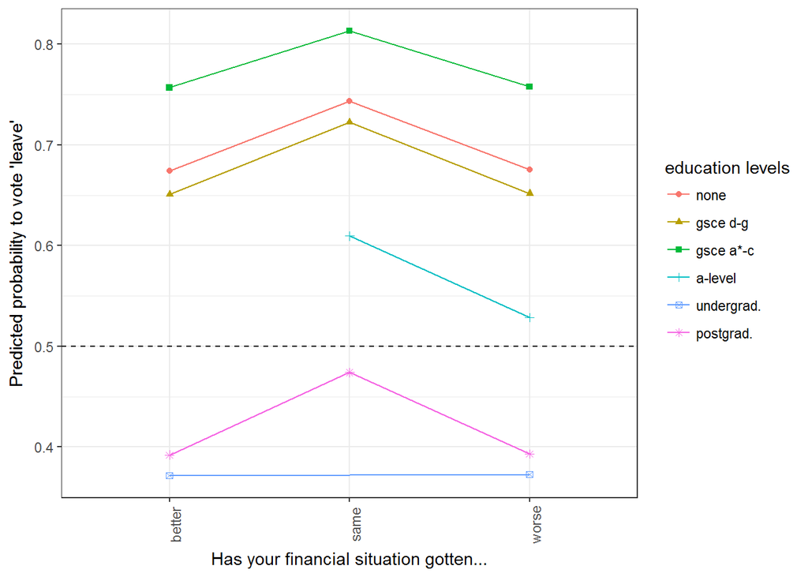

```r
nd2 <- data.table(
  pers.fin=rep(levels(bx$pers.fin),each=5),
  age.c=rep(mean(bx$age.c,na.rm=TRUE),15),
  female=rep(0,15),
  ed.c=rep(levels(factor(bx$ed.c)),3),
  vote.rec2=rep("conservative",15),
  ukip.share=rep(mean(ukip$ukip.share),15),
  dep4=rep(mean(deprived$dep4),15),
  pop.dens=rep(mean(pop.dens$pop.dens),15),
  unemp_long=rep(0,15),
  unemp_short=rep(0,15)
  )

nd2$pred.pop <- predict(model3.1,newdata=nd2,type="response",re.form=NA)

qplot(x=pers.fin,y=pred.pop,data=nd2,colour=factor(ed.c),group=factor(ed.c),shape=factor(ed.c)) +
      geom_line() +
      theme_bw() +
      geom_hline(yintercept=.5,linetype="dashed") +
      ylab("Predicted probability to vote 'leave'") +
      xlab("Has your financial situation gotten...") +
      scale_color_brewer(palette="Dark2",type="qual") +
      theme(axis.text.x=element_text(angle=90)) +
      scale_colour_discrete(name="education levels",
                     breaks=c(levels(factor(bx$ed.c))),
                     labels=c("none", "gsce d-g", "gsce a*-c", "a-level", "undergrad.", "postgrad.")) +
      scale_shape_discrete(name="education levels",
                     breaks=c(levels(factor(bx$ed.c))),
                     labels=c("none", "gsce d-g", "gsce a*-c", "a-level", "undergrad.", "postgrad."))
```

Which leads me to want to try an interaction between education and personal economy, because this shape could as well vary.

### Model 3.2 second go—added income categories and perceived class

Note: now i can see that the second level predictors won’t work until I put them on the city level, to have enough variation. Now I prioritise the exploration of the individual-level variables. I will re-reun these models with second-level predictors later.

In this model I’m trying to add the income variable and the perception of class variable from the pre-referendum wave. Effective sample size will decrease due to missingness, see below. The distribution of class is:

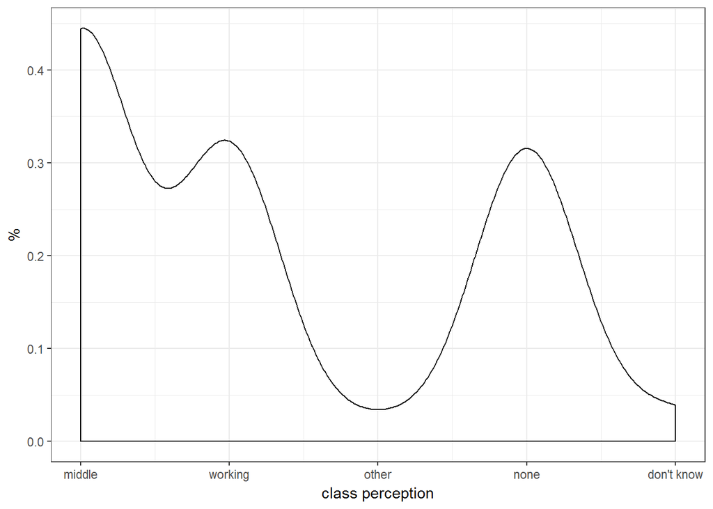

```r
bx.pre <- as.data.table(read.csv("bx.pre.csv")) #RecipientEmail
bx <- merge(bx,bx.full[,c("ResponseId","RecipientEmail"),with=FALSE],by.x="token",by.y="ResponseId",all.x=TRUE)
bx <- merge(bx,bx.pre[,c(12,53,55),with=FALSE],by="RecipientEmail",all.x=TRUE)

qplot(Q26,data=bx,geom="density") + theme_bw() + xlab("class perception") + ylab("%") + scale_x_continuous(breaks=c(1,2,3,4,5),labels=c("middle", "working", "other", "none", "don't know"))
```

which makes me wonder who to compare with whom, without loosing data. I am going to go with middle class vs. anything else (including ‘none’) as well as working class vs. anything else (including ‘none’).

```r
bx$middle.class <- factor("other",levels=c("other","middle"))
bx$middle.class[bx$Q26==5] <- NA
bx$middle.class[is.na(bx$Q26)] <- NA
bx$middle.class[bx$Q26==1] <- "middle"

bx$working.class <- factor("other",levels=c("other","working"))
bx$working.class[bx$Q26==5] <- NA
bx$working.class[is.na(bx$Q26)] <- NA
bx$working.class[bx$Q26==2] <- "working"

model3.2 <- glmer(leave ~ 1 + ( 1 | region) +
                    scale(age.c) + factor(female) + ordered(factor(ed.c)) + vote.rec2 +
                    factor(unemp_short) + factor(unemp_long) + pers.fin + Q75 + middle.class + working.class,
                  weights=w, data=bx, family=binomial(link="logit"),control = glmerControl(optimizer = "bobyqa"),nAGQ = 10)

summary(model3.2)
```

```
## Generalized linear mixed model fit by maximum likelihood (Adaptive Gauss-Hermite Quadrature, nAGQ = 10) ['glmerMod']
##  Family: binomial  ( logit )
## Formula: leave ~ 1 + (1 | region) + scale(age.c) + factor(female) + ordered(factor(ed.c)) +      vote.rec2 + factor(unemp_short) + factor(unemp_long) + pers.fin +      Q75 + middle.class + working.class
##    Data: bx
## Weights: w
## Control: glmerControl(optimizer = "bobyqa")
##
##      AIC      BIC   logLik deviance df.resid
##    367.8    441.6   -162.9    325.8      228
##
## Scaled residuals:
##     Min      1Q  Median      3Q     Max
## -4.8699 -0.5843 -0.2324  0.4356  9.5104
##
## Random effects:
##  Groups Name        Variance Std.Dev.
##  region (Intercept) 1.097    1.047
## Number of obs: 249, groups:  region, 10
##
## Fixed effects:
##                         Estimate Std. Error z value Pr(>|z|)
## (Intercept)              1.97465    0.75695   2.609 0.009089 **
## scale(age.c)            -0.27064    0.21076  -1.284 0.199119
## factor(female)1          0.49817    0.32680   1.524 0.127406
## ordered(factor(ed.c)).L -1.04603    0.69085  -1.514 0.129999
## ordered(factor(ed.c)).Q  0.16672    0.52930   0.315 0.752781
## ordered(factor(ed.c)).C -0.55445    0.66190  -0.838 0.402217
## ordered(factor(ed.c))^4  0.39194    0.62703   0.625 0.531920
## ordered(factor(ed.c))^5  0.05504    0.43813   0.126 0.900026
## vote.rec2labour         -1.96201    0.41776  -4.696 2.65e-06 ***
## vote.rec2libdem         -2.42760    0.61102  -3.973 7.10e-05 ***
## vote.rec2ukip            2.84211    0.78274   3.631 0.000282 ***
## vote.rec2other          -1.69217    0.52672  -3.213 0.001315 **
## vote.rec2none           -4.15291    1.10302  -3.765 0.000167 ***
## factor(unemp_short)1    -1.95592    1.22219  -1.600 0.109524
## factor(unemp_long)1     -0.92871    1.84900  -0.502 0.615472
## pers.fin.L               0.55535    0.32749   1.696 0.089929 .
## pers.fin.Q               0.82626    0.27119   3.047 0.002313 **
## Q75                     -0.19826    0.05092  -3.893 9.88e-05 ***
## middle.classmiddle       1.34513    0.44189   3.044 0.002334 **
## working.classworking     0.47967    0.40191   1.193 0.232682
## ---
## Signif. codes:  0 '***' 0.001 '**' 0.01 '*' 0.05 '.' 0.1 ' ' 1
```

The current number of obs is 249, so even if this looks interesting, I am really not sure if we should include this. But okay, we wanted to see (1) the effect of class perception (middle class identification has a positive effect on leave, I’d put this in the context of the rhetoric of the conservative side, rather than anything else); (2) the effect of income (Q75, negative significant meaning higher income - remain vote); and to look at a possible interaction between income and the evaluation of change in personal finances. See below:

### Model 3.3: Interaction income and perception of change in personal finances

```r
model3.3 <- glmer(leave ~ 1 + ( 1 | region) +
                    scale(age.c) + factor(female) + ordered(factor(ed.c)) + vote.rec2 +
                    factor(unemp_short) + factor(unemp_long) + pers.fin + Q75 + pers.fin:Q75 + middle.class + working.class,
                  weights=w, data=bx, family=binomial(link="logit"),control = glmerControl(optimizer = "bobyqa"),nAGQ = 10)

summary(model3.3)
```

```
## Generalized linear mixed model fit by maximum likelihood (Adaptive Gauss-Hermite Quadrature, nAGQ = 10) ['glmerMod']
##  Family: binomial  ( logit )
## Formula: leave ~ 1 + (1 | region) + scale(age.c) + factor(female) + ordered(factor(ed.c)) +      vote.rec2 + factor(unemp_short) + factor(unemp_long) + pers.fin +      Q75 + pers.fin:Q75 + middle.class + working.class
##    Data: bx
## Weights: w
## Control: glmerControl(optimizer = "bobyqa")
##
##      AIC      BIC   logLik deviance df.resid
##    365.7    446.6   -159.9    319.7      226
##
## Scaled residuals:
##     Min      1Q  Median      3Q     Max
## -4.6464 -0.6018 -0.2255  0.4264  8.2641
##
## Random effects:
##  Groups Name        Variance Std.Dev.
##  region (Intercept) 0.9529   0.9762
## Number of obs: 249, groups:  region, 10
##
## Fixed effects:
##                         Estimate Std. Error z value Pr(>|z|)
## (Intercept)              2.47815    0.79364   3.123 0.001793 **
## scale(age.c)            -0.32219    0.21422  -1.504 0.132576
## factor(female)1          0.46571    0.32906   1.415 0.156983
## ordered(factor(ed.c)).L -0.98003    0.72436  -1.353 0.176072
## ordered(factor(ed.c)).Q  0.02573    0.56859   0.045 0.963900
## ordered(factor(ed.c)).C -0.26682    0.70299  -0.380 0.704283
## ordered(factor(ed.c))^4  0.22224    0.66333   0.335 0.737592
## ordered(factor(ed.c))^5  0.16062    0.46070   0.349 0.727356
## vote.rec2labour         -1.97427    0.41959  -4.705 2.54e-06 ***
## vote.rec2libdem         -2.40497    0.62631  -3.840 0.000123 ***
## vote.rec2ukip            2.79919    0.77965   3.590 0.000330 ***
## vote.rec2other          -1.57951    0.53582  -2.948 0.003200 **
## vote.rec2none           -4.48015    1.20965  -3.704 0.000212 ***
## factor(unemp_short)1    -2.67229    1.34762  -1.983 0.047370 *
## factor(unemp_long)1     -1.18927    1.89511  -0.628 0.530299
## pers.fin.L               0.13094    0.80872   0.162 0.871377
## pers.fin.Q               2.13646    0.63148   3.383 0.000716 ***
## Q75                     -0.25123    0.05804  -4.328 1.50e-05 ***
## middle.classmiddle       1.28600    0.45448   2.830 0.004661 **
## working.classworking     0.37545    0.40983   0.916 0.359606
## pers.fin.L:Q75           0.08576    0.10118   0.848 0.396693
## pers.fin.Q:Q75          -0.17988    0.07540  -2.386 0.017043 *
## ---
## Signif. codes:  0 '***' 0.001 '**' 0.01 '*' 0.05 '.' 0.1 ' ' 1
```

```r
nd3 <- bx[!is.na(pers.fin) & !is.na(Q75) & !is.na(ed.c),.N,by=list(pers.fin,Q75,ed.c)][order(pers.fin,Q75,ed.c)][,1:3,with=FALSE]
nd3$age.c <- mean(bx$age.c,na.rm=TRUE)
nd3$female <- 0
nd3$vote.rec2 <- "conservative"
nd3$unemp_long <- 0
nd3$unemp_short <- 0
nd3$middle.class <- "middle"
nd3$working.class <- "other"

nd3$pred.pop <- predict(model3.3,newdata=nd3,type="response",re.form=NA)
nd3$ed.c <- factor(nd3$ed.c,levels=c(levels(factor(nd3$ed.c))),labels=c("none","gsce low","gsce high","a-lev","undergrad","postgrad"))

nd3$income <- factor(NA,levels=c("<25%","25-50%","50-75%",">75%"))
nd3$income[nd3$Q75 < 6] <- "<25%"
nd3$income[nd3$Q75 >= 6 & nd3$Q75 < 9] <- "25-50%"
nd3$income[nd3$Q75 >= 9 & nd3$Q75 < 12] <- "50-75%"
nd3$income[nd3$Q75 >= 12] <- ">75%"
nd3 <- nd3[,mean(pred.pop),by=list(pers.fin,income,ed.c)]
```

```
  the interaction looks like this, by education categories:
```

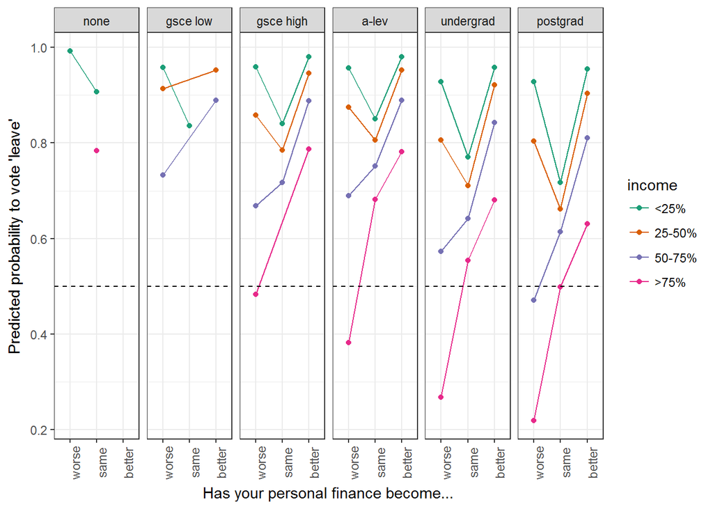

```r
qplot(x=pers.fin,y=V1,data=nd3,colour=income,group=income) +
  geom_line() +
  theme_bw() +
  geom_hline(yintercept=.5,linetype="dashed") +
  ylab("Predicted probability to vote 'leave'") +
  xlab("Has your personal finance become...") +
  scale_color_brewer(palette="Dark2",type="qual") +
  theme(axis.text.x=element_text(angle=90)) +
  facet_grid(. ~ ed.c)
```